# BF_Finals 23

#### Plot the decomposition of the time series

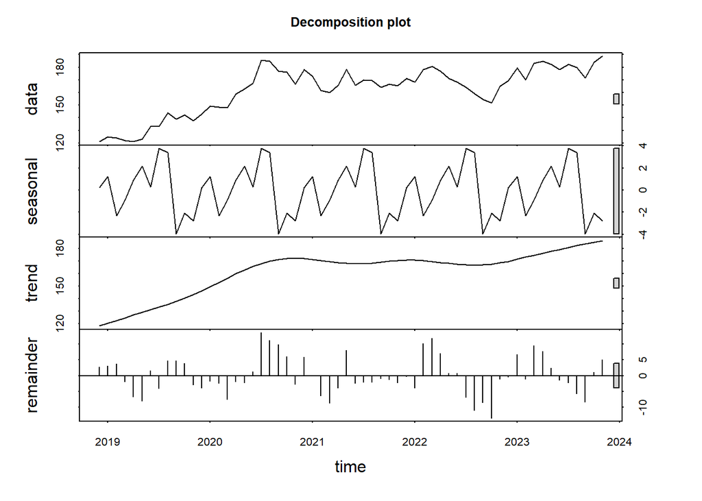

```r
stl_decomp <- stl(TS_win,s.window ="periodic")
plot(stl_decomp, main = 'Decomposition plot')
```

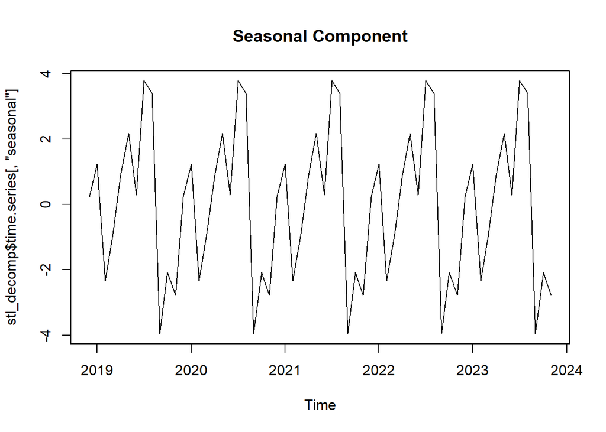

```r
# Plot the seasonal component
plot(stl_decomp$time.series[, "seasonal"], main="Seasonal Component")
```

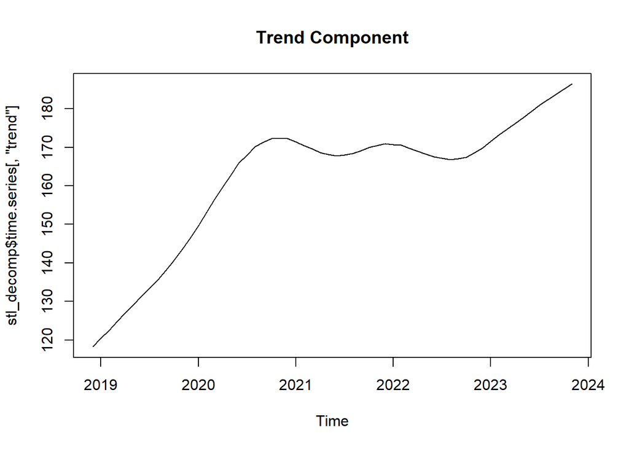

```r
# Plot the trend component
plot(stl_decomp$time.series[, "trend"], main="Trend Component")
```

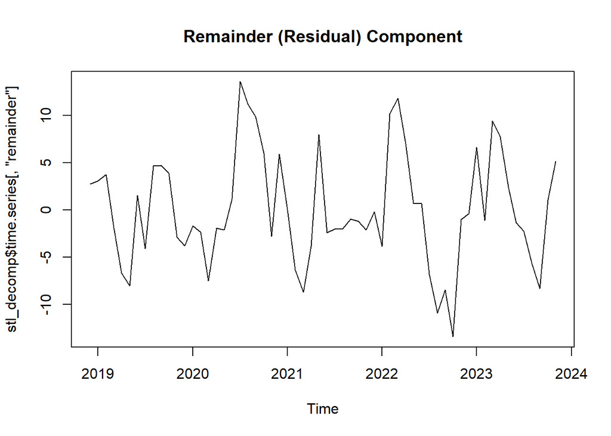

```r
# Plot the remainder component
plot(stl_decomp$time.series[, "remainder"], main="Remainder (Residual) Component")
```

```r
# Attributes of stl
attributes(stl_decomp)
```

```
## $names
## [1] "time.series" "weights"     "call"        "win"         "deg"
## [6] "jump"        "inner"       "outer"
##
## $class
## [1] "stl"
```

```r
str(stl_decomp)
```

```
## List of 8
##  $ time.series: Time-Series [1:60, 1:3] from 2019 to 2024: 0.242 1.247 -2.333 -0.909 0.901 ...
##   ..- attr(*, "dimnames")=List of 2
##   .. ..$ : NULL
##   .. ..$ : chr [1:3] "seasonal" "trend" "remainder"
##  $ weights    : num [1:60] 1 1 1 1 1 1 1 1 1 1 ...
##  $ call       : language stl(x = TS_win, s.window = "periodic")
##  $ win        : Named num [1:3] 601 19 13
##   ..- attr(*, "names")= chr [1:3] "s" "t" "l"
##  $ deg        : Named int [1:3] 0 1 1
##   ..- attr(*, "names")= chr [1:3] "s" "t" "l"
##  $ jump       : Named num [1:3] 61 2 2
##   ..- attr(*, "names")= chr [1:3] "s" "t" "l"
##  $ inner      : int 2
##  $ outer      : int 0
##  - attr(*, "class")= chr "stl"
```

- As per observation data seems to be uniformly seasonal after extracting the seasonal component indicative addtitive decomposition
- Trend seems to be not uniform and random in nature (increasing and decreasing randomly)
- Residuals seem to be repetitive for STL decomposition similar to seasonality pattern in STL decomposition.

#### Is the times series seasonal?

- Yes, the times series has a seasonal component as per above visualizations(charts).

#### Is the decomposition additive or multiplicative?

```r
decompose <- decompose(TS_win)
decompose$type
```

```
## [1] "additive"
```

#### If seasonal, what are the values of the seasonal monthly indices?

```r
decompose$figure
```

```
##  [1]  0.04823710  0.96188338 -2.70030316 -0.03499122  2.76417765  3.94511537
##  [7]  0.14365490  3.54521961  3.74386415 -3.03572394 -3.75832841 -5.62280544
```

#### Show the plot for time series adjusted for seasonality. Overlay this with the line for actual time series? Does seasonality have big fluctuations to the value of time series?

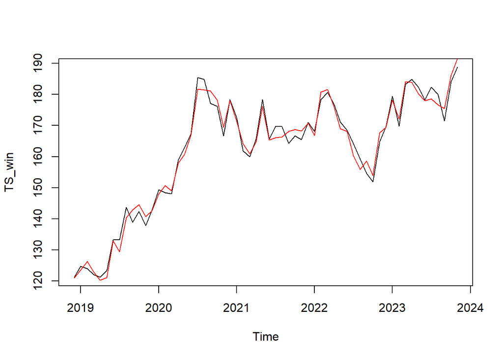

```r
plot(TS_win)
lines(seasadj(stl_decomp), main = "Seasonally adjusted plot", col="Red")
```

As per the plot, we can assume seasonality does not have big fluctuations to gold prize values.

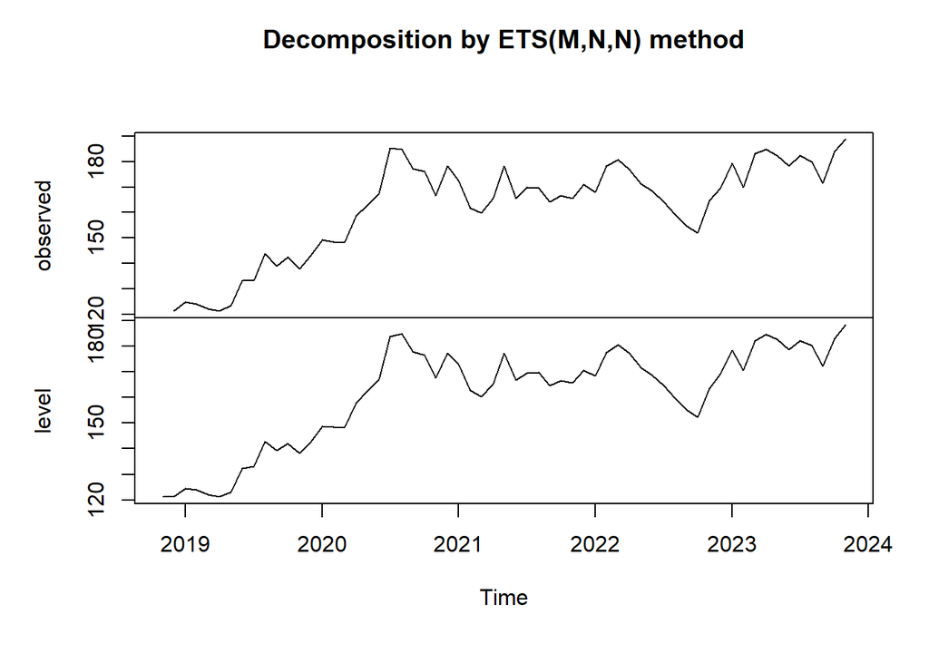

```r
ETS_TS <- ets(TS_win)
plot(ETS_TS)
```

```r
attributes(ETS_TS)
```

```
## $names
##  [1] "loglik"     "aic"        "bic"        "aicc"       "mse"
##  [6] "amse"       "fit"        "residuals"  "fitted"     "states"
## [11] "par"        "m"          "method"     "series"     "components"
## [16] "call"       "initstate"  "sigma2"     "x"
##
## $class
## [1] "ets"
```

```r
ETS_TS$mse
```

```
## [1] 46.55642
```

## Naive Method

#### Output

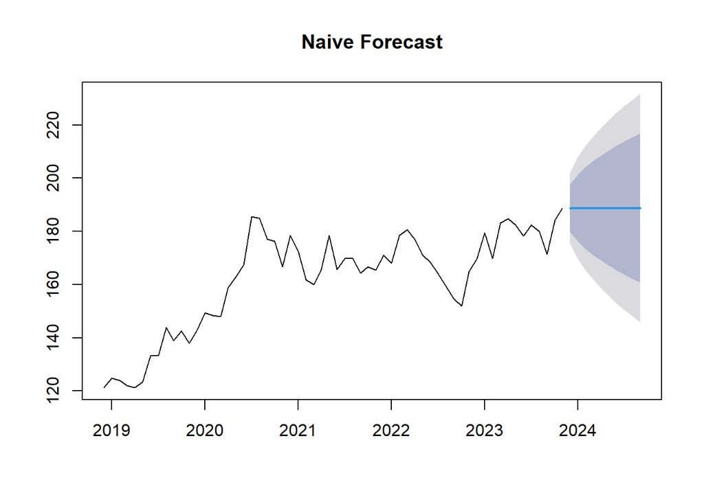

```r
TS_naive = naive(TS_win)
plot(TS_naive, main = "Naive Forecast")
```

```r
attributes(TS_naive)
```

```
## $names
##  [1] "method"    "model"     "lambda"    "x"         "fitted"    "residuals"
##  [7] "series"    "mean"      "level"     "lower"     "upper"
##
## $class
## [1] "forecast"
```

#### Perform Residual Analysis for this technique.

###### Do a plot of residuals. What does the plot indicate?

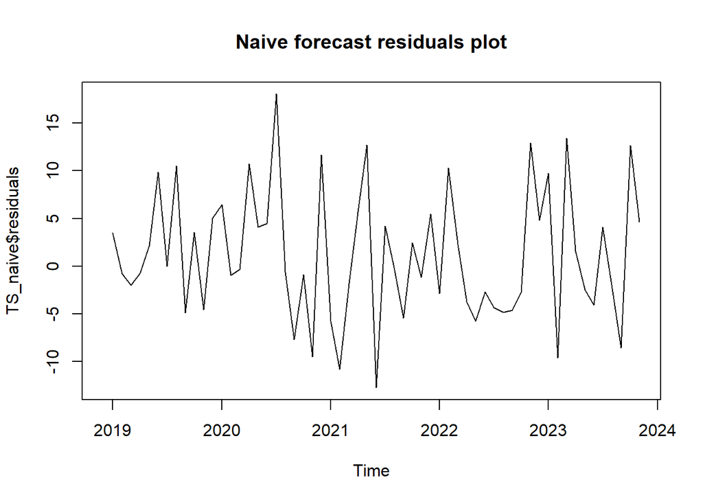

```r
plot(TS_naive$residuals, main = "Naive forecast residuals plot")
```

- The residuals deduce that there is randomness in error indicating that naive is not missing out important components of data
- The residuals values seems to fluctuate positively and negatively around 0 indicating mean to be close to 0

###### Do a Histogram plot of residuals. What does the plot indicate?

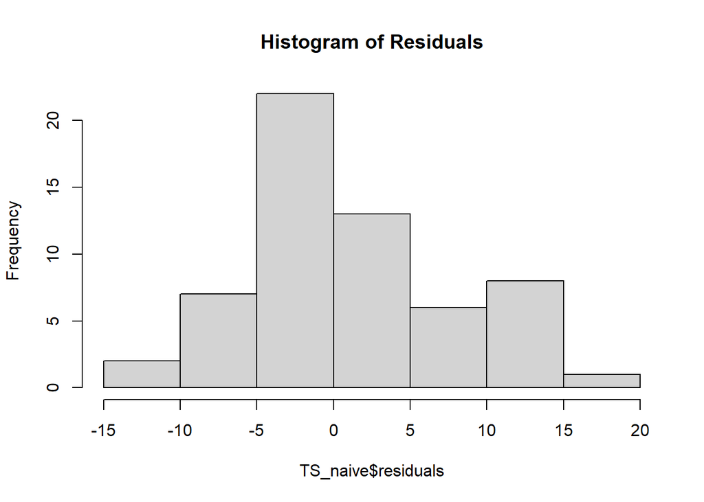

```r
hist(TS_naive$residuals, main ='Histogram of Residuals')
```

###### Do a plot of fitted values vs. residuals. What does the plot indicate?

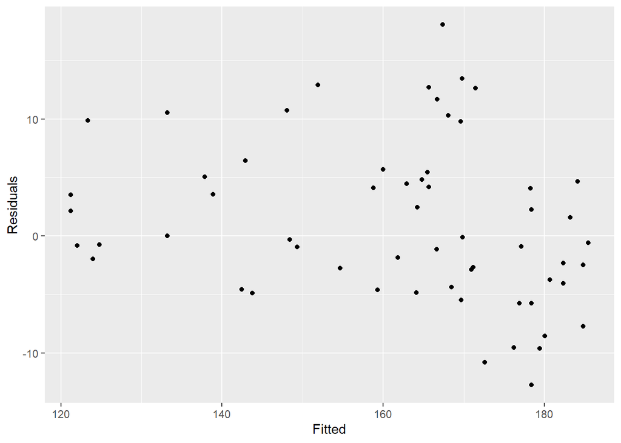

```r
cbind(Fitted = fitted(TS_naive),
      Residuals=residuals(TS_naive)) %>%
  as.data.frame() %>%
  ggplot(aes(x=Fitted, y=Residuals)) + geom_point()
```

- The Fitted vs. Residuals plot displays an irregular pattern, suggesting that the errors exhibit randomness. This randomness indicates that the variance of the residuals lacks consistency and doesn’t follow any discernible pattern.

###### Do a plot of actual values vs. residuals. What does the plot indicate?

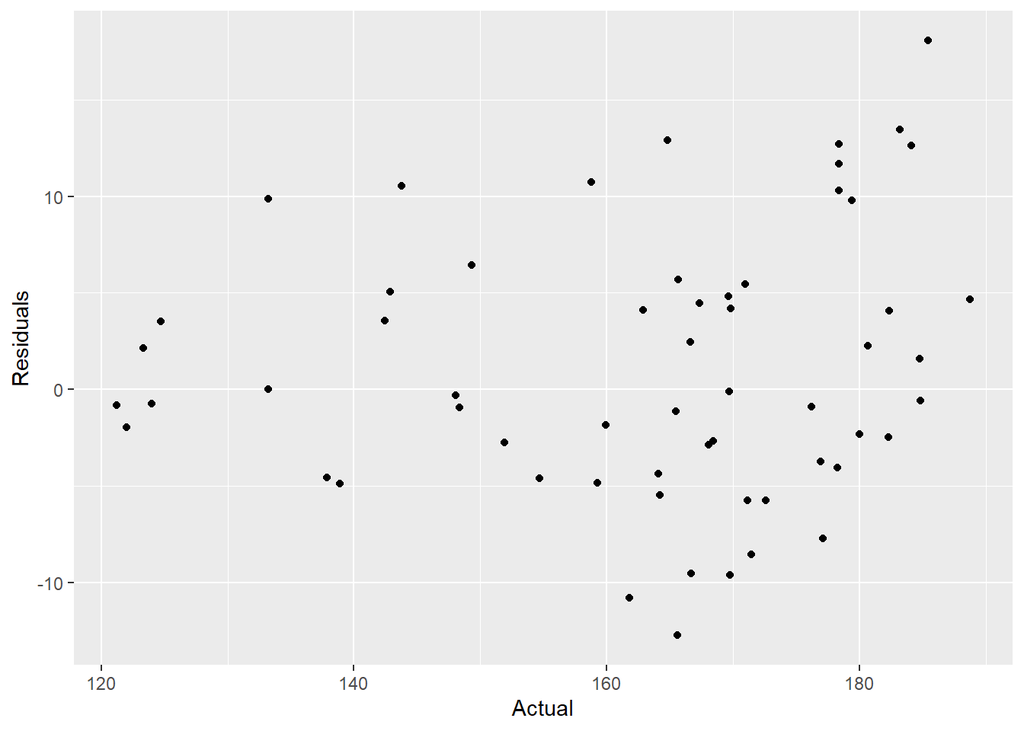

```r
cbind(Actual = TS_win,
      Residuals=residuals(TS_naive)) %>%
  as.data.frame() %>%
  ggplot(aes(x=Actual, y=Residuals)) + geom_point()
```

###### Do an ACF plot of the residuals? What does this plot indicate?

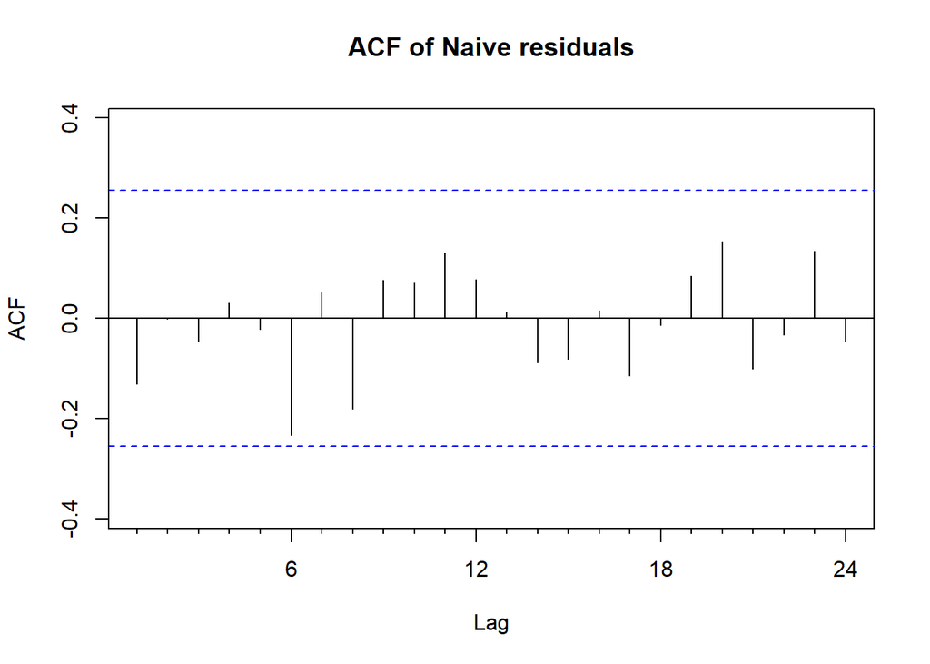

```r
Acf(TS_naive$residuals, main = "ACF of Naive residuals")
```

- Values of the Acf are close to confidence level at certain lags t-6 and t-20 indicating a slight pattern in error indicating naive is missing out on an important component (possibly seasonality).
- The Acf values also show a pattern hence we can use a better forecast algorithm

## Print the 5 measures of accuracy for this forecasting technique

```r
naive_accuracy <- accuracy(TS_naive)
naive_accuracy
```

```
##                    ME     RMSE      MAE       MPE     MAPE      MASE       ACF1
## Training set 1.144068 6.916201 5.537627 0.6631645 3.352577 0.3161084 -0.1301814
```

#### Forecast

###### Time series value for next year. Show table and plot

```r
forecast(TS_naive)
```

```
##          Point Forecast    Lo 80    Hi 80    Lo 95    Hi 95
## Dec 2023         188.75 179.8865 197.6135 175.1945 202.3055
## Jan 2024         188.75 176.2152 201.2848 169.5796 207.9204
## Feb 2024         188.75 173.3980 204.1020 165.2712 212.2288
## Mar 2024         188.75 171.0231 206.4769 161.6390 215.8610
## Apr 2024         188.75 168.9307 208.5693 158.4390 219.0610
## May 2024         188.75 167.0390 210.4610 155.5459 221.9541
## Jun 2024         188.75 165.2995 212.2005 152.8855 224.6145
## Jul 2024         188.75 163.6803 213.8197 150.4092 227.0908
## Aug 2024         188.75 162.1596 215.3404 148.0835 229.4165
## Sep 2024         188.75 160.7213 216.7787 145.8837 231.6163
```

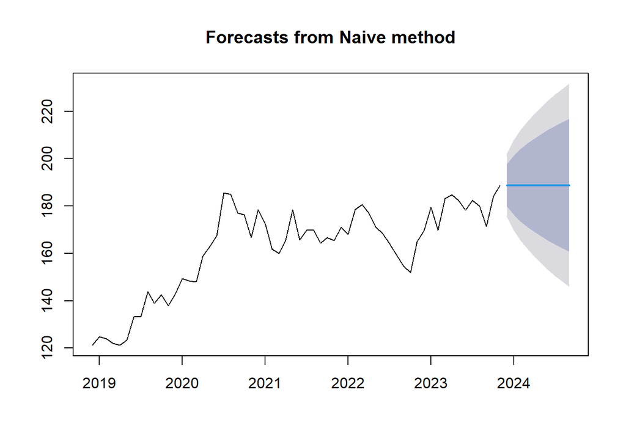

```r
plot(forecast(TS_naive))
```

#### Summarize this forecasting technique

###### How good is the accuracy?

- Altough the accuracy values are low indicating a good forecast, we can utilize a better algorithm suited for seasonality component in data
- Also RMSE values are little high indicating that we can improve on our forecast.

###### What does it predict the value of time series will be in one year?

- 188.75

###### Other observation

- Naive seems good forecasting technique for the following data as it yields a very low accuracy values for errors indicating a good forecast.
- It is observed that there is a uniform seasonality component indicating we can add on or use better algorithm to forecast if the errors are lower.

## Simple Moving Averages

#### Plot the graph for time series

#### Show the Simple Moving average of order 3 on the plot above in Red

#### Show the Simple Moving average of order 6 on the plot above in Blue

#### Show the Simple Moving average of order 9 on the plot above in Green

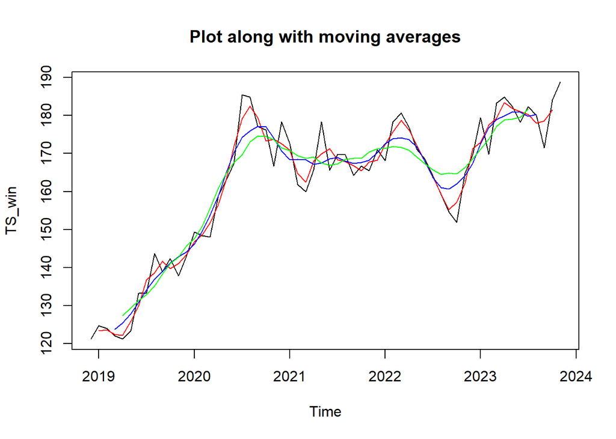

```r
mavg3_forecast = ma(TS_win,order=3)
mavg6_forecast = ma(TS_win,order=6)
mavg9_forecast = ma(TS_win,order=9)
plot(TS_win, main = "Plot along with moving averages")
lines(mavg3_forecast, col="Red")
lines(mavg6_forecast, col="Blue")
lines(mavg9_forecast, col="Green")
```

- The Red line (order 3) gives the most real data compared to the other two. The higher order averages smoother the plot and do not give the actual values.

#### (Bonus) show the forecast of next 12 months using one of the simple average order that you feel works best for time series

```r
MA3_forecast <- forecast(mavg3_forecast, h = 12)
```

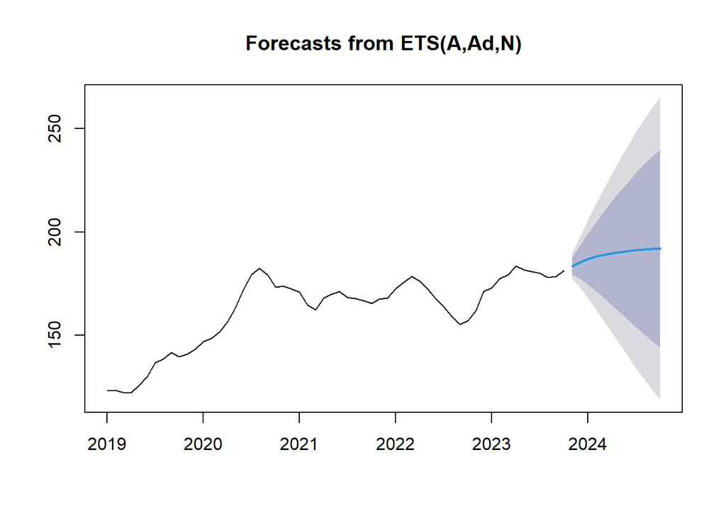

```r
plot(MA3_forecast)
```

#### What are your observations of the plot as the moving average order goes up?

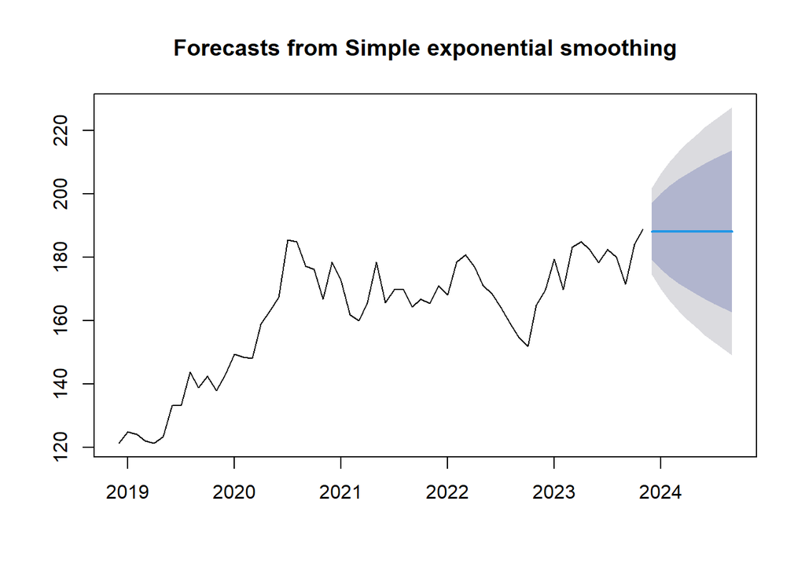

```r
ses_data <- ses(TS_win)
plot(ses_data)
```

###### What is the value of alpha? What does that value signify?

###### What is the value of initial state?

###### What is the value of sigma? What does the sigma signify?

```r
summary(ses_data)
```

```
##
## Forecast method: Simple exponential smoothing
##
## Model Information:
## Simple exponential smoothing
##
## Call:
##  ses(y = TS_win)
##
##   Smoothing parameters:
##     alpha = 0.8983
##
##   Initial states:
##     l = 121.59
##
##   sigma:  6.9394
##
##      AIC     AICc      BIC
## 482.0925 482.5210 488.3755
##
## Error measures:
##                    ME     RMSE      MAE       MPE     MAPE      MASE
## Training set 1.234966 6.822766 5.484528 0.7166804 3.319371 0.3130774
##                     ACF1
## Training set -0.03335681
##
## Forecasts:
##          Point Forecast    Lo 80    Hi 80    Lo 95    Hi 95
## Dec 2023       188.1548 179.2616 197.0480 174.5538 201.7558
## Jan 2024       188.1548 176.2001 200.1095 169.8717 206.4379
## Feb 2024       188.1548 173.7764 202.5333 166.1649 210.1448
## Mar 2024       188.1548 171.7059 204.6037 162.9984 213.3112
## Apr 2024       188.1548 169.8685 206.4412 160.1883 216.1214
## May 2024       188.1548 168.1995 208.1102 157.6357 218.6739
## Jun 2024       188.1548 166.6597 209.6500 155.2808 221.0288
## Jul 2024       188.1548 165.2230 211.0866 153.0837 223.2259
## Aug 2024       188.1548 163.8712 212.4384 151.0163 225.2933
## Sep 2024       188.1548 162.5908 213.7188 149.0581 227.2516
```

##### Perform Residual Analysis for this technique

###### Do a plot of residuals. What does the plot indicate?

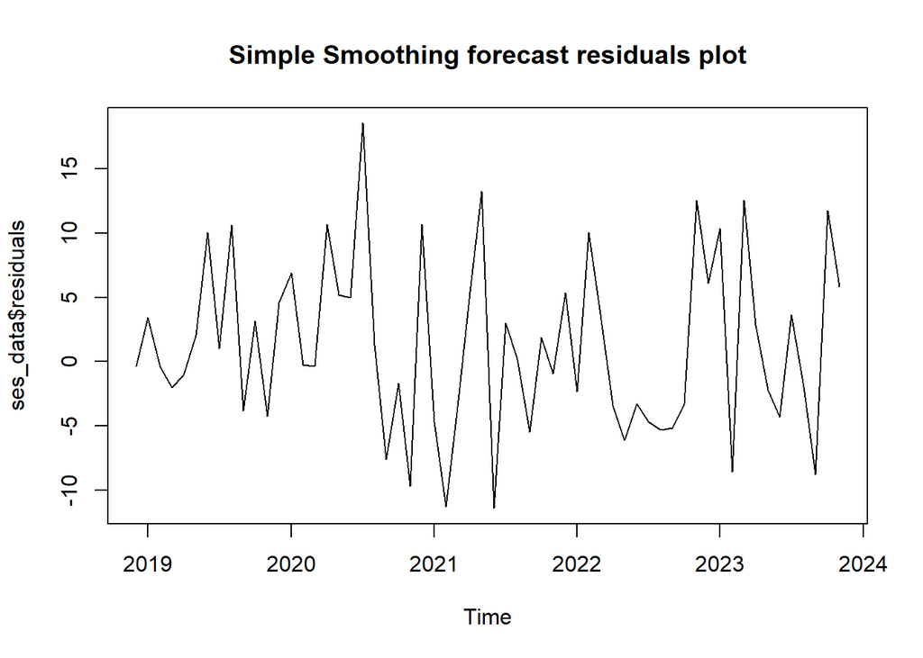

```r
plot(ses_data$residuals, main = "Simple Smoothing forecast residuals plot")
```

* The residuals deduce that there is randomness in error indicating that simple smoothing may not miss out important components of data. * The residuals values seems to fluctuate positively and negatively around 0 indicating mean to be close to 0 * The residuals appear to have seasonality. * Ideally, there shouldn’t have any trend, pattern, or seasonality.

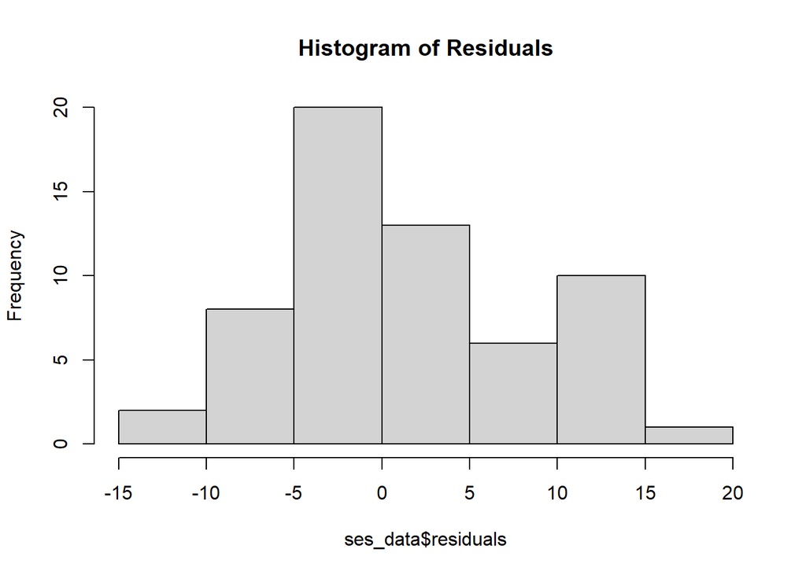

```r
hist(ses_data$residuals, main ='Histogram of Residuals')
```

###### Do a plot of fitted values vs. residuals. What does the plot indicate?

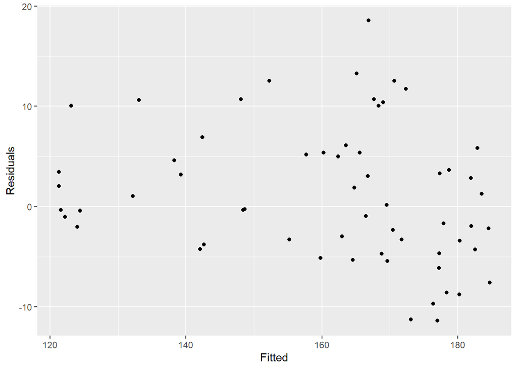

```r
cbind(Fitted = fitted(ses_data),
      Residuals=residuals(ses_data)) %>%
  as.data.frame() %>%
  ggplot(aes(x=Fitted, y=Residuals)) + geom_point()
```

- The Fitted vs. Residuals plot displays an irregular pattern, suggesting that the errors exhibit randomness.
- This randomness indicates that the variance of the residuals lacks consistency and doesn’t follow any discernible pattern.

###### Do a plot of actual values vs. residuals. What does the plot indicate?

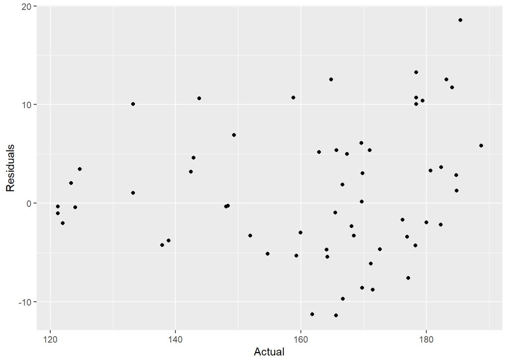

```r
cbind(Actual = TS_win,
      Residuals=residuals(ses_data)) %>%
  as.data.frame() %>%
  ggplot(aes(x=Actual, y=Residuals)) + geom_point()
```

###### Do an ACF plot of the residuals? What does this plot indicate?

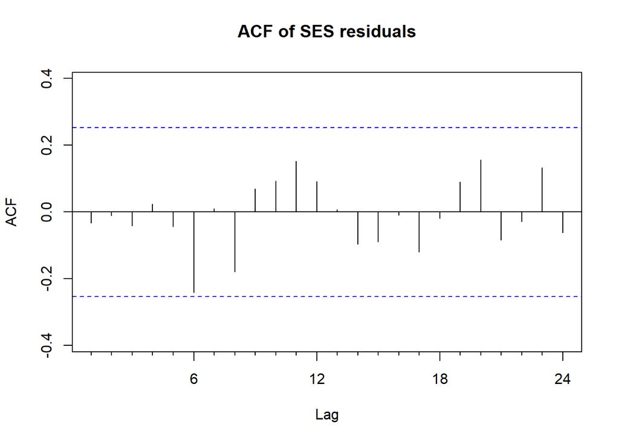

```r
Acf(ses_data$residuals, main = "ACF of SES residuals")
```

* Values of the Acf are close to confidence level at certain lags t-6 and t-20 indicating a slight pattern in error indicating SSE might missing out on an important component (possibly seasonality). * The Acf values also show a pattern hence we can use a better forecast algorithm

## Print the 5 measures of accuracy for this forecasting technique

```r
ses_accuracy <- accuracy(ses_data)
ses_accuracy
```

```
##                    ME     RMSE      MAE       MPE     MAPE      MASE
## Training set 1.234966 6.822766 5.484528 0.7166804 3.319371 0.3130774
##                     ACF1
## Training set -0.03335681
```

#### Forecast

###### Time series value for next year. Show table and plot

```r
forecast(ses_data)
```

```
##          Point Forecast    Lo 80    Hi 80    Lo 95    Hi 95
## Dec 2023       188.1548 179.2616 197.0480 174.5538 201.7558
## Jan 2024       188.1548 176.2001 200.1095 169.8717 206.4379
## Feb 2024       188.1548 173.7764 202.5333 166.1649 210.1448
## Mar 2024       188.1548 171.7059 204.6037 162.9984 213.3112
## Apr 2024       188.1548 169.8685 206.4412 160.1883 216.1214
## May 2024       188.1548 168.1995 208.1102 157.6357 218.6739
## Jun 2024       188.1548 166.6597 209.6500 155.2808 221.0288
## Jul 2024       188.1548 165.2230 211.0866 153.0837 223.2259
## Aug 2024       188.1548 163.8712 212.4384 151.0163 225.2933
## Sep 2024       188.1548 162.5908 213.7188 149.0581 227.2516
```

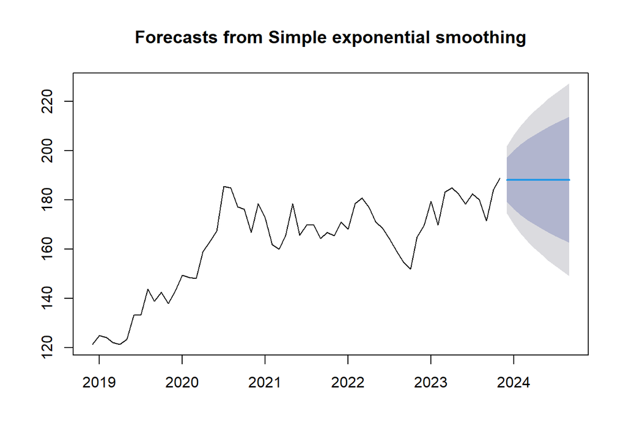

```r
plot(forecast(ses_data))
```

#### Summarize this forecasting technique

###### Other observation

- It is observed that there is a seasonality in the data. So, simple smoothing forecast may not be a right way to forecast.
- We can consider more forecasting techniques and check if the error values are less than this one and also which include seasonality.